# M3P Data Analysis

Elise

2024-06-09

Set the right working directory.

```r
setwd("C:/Users/elise/Documents/Mémoire/Main/Data/Templates/M3P")
```

# Data importation

Import the data sets extracted from the Data Preparation R Markdown.

```r
list.files()
```

```
##  [1] "endpoint.txt"
##  [2] "plant_info.txt"
##  [3] "S_timeseries.txt"
##  [4] "T_timeseries.txt"
##  [5] "timeseries.txt"
##  [6] "timeseries_Leaf_number.txt"
##  [7] "timeseries_Ligulated_leaf_number.txt"
##  [8] "timeseries_Plant_emergence.txt"
##  [9] "timeseries_Plant_transpiration.txt"
## [10] "timeseries_Soil_water_potential.txt"
## [11] "timeseries_Water.txt"
```

```r
plant_info <- read.table("plant_info.txt", header = TRUE, sep = "\t")
endpoint <- read.table("endpoint.txt", header = TRUE, sep = "\t")
timeseries <- read.table("timeseries.txt", header = TRUE, sep = "\t")
timeseries_Plant_emergence <- read.table("timeseries_Plant_emergence.txt", header = TRUE, sep = "\t")
timeseries_Plant_transpiration <- read.table("timeseries_Plant_transpiration.txt", header = TRUE, sep = "\t")
timeseries_Soil_water_potential <- read.table("timeseries_Soil_water_potential.txt", header = TRUE, sep = "\t")
timeseries_Ligulated_leaf_number <- read.table("timeseries_Ligulated_leaf_number.txt", header = TRUE, sep = "\t")
timeseries_Water <- read.table("timeseries_Water.txt", header = TRUE, sep = "\t")
timeseries_Leaf_number <- read.table("timeseries_Leaf_number.txt", header = TRUE, sep = "\t")
S_timeseries <- read.table("S_timeseries.txt", header = TRUE, sep = "\t")
```

Convert the columns to factor and date formats.

```r
# plant_info
plant_info <- lapply(plant_info, factor)

# endpoint
matching_cols <- intersect(names(endpoint), names(plant_info))
endpoint[, matching_cols] <- lapply(endpoint[, matching_cols], factor)
endpoint$Date <- date(endpoint$Date)
endpoint$Timestamp <- NA

# timeseries_Plant_transpiration
matching_cols <- intersect(names(timeseries_Plant_transpiration), names(plant_info))
timeseries_Plant_transpiration[, matching_cols] <- lapply(timeseries_Plant_transpiration[, matching_cols], factor)
timeseries_Plant_transpiration$Timestamp <- as.POSIXct(timeseries_Plant_transpiration$Timestamp, format = "%Y-%m-%d %H:%M:%S")
timeseries_Plant_transpiration$Date <- date(timeseries_Plant_transpiration$Date)

# timeseries_Leaf_number
matching_cols <- intersect(names(timeseries_Leaf_number), names(plant_info))
timeseries_Leaf_number[, matching_cols] <- lapply(timeseries_Leaf_number[, matching_cols], factor)
timeseries_Leaf_number$Timestamp <- as.POSIXct(timeseries_Leaf_number$Timestamp, format = "%Y-%m-%d %H:%M:%S")
timeseries_Leaf_number$Date <- date(timeseries_Leaf_number$Date)

# timeseries_Soil_water_potential
matching_cols <- intersect(names(timeseries_Soil_water_potential), names(plant_info))
timeseries_Soil_water_potential[, matching_cols] <- lapply(timeseries_Soil_water_potential[, matching_cols], factor)
timeseries_Soil_water_potential$Timestamp <- as.POSIXct(timeseries_Soil_water_potential$Timestamp, format = "%Y-%m-%d %H:%M:%S")
timeseries_Soil_water_potential$Date <- date(timeseries_Soil_water_potential$Date)

# timeseries_Ligulated_leaf_number
matching_cols <- intersect(names(timeseries_Ligulated_leaf_number), names(plant_info))
timeseries_Ligulated_leaf_number[, matching_cols] <- lapply(timeseries_Ligulated_leaf_number[, matching_cols], factor)
timeseries_Ligulated_leaf_number$Timestamp <- as.POSIXct(timeseries_Ligulated_leaf_number$Timestamp, format = "%Y-%m-%d %H:%M:%S")
timeseries_Ligulated_leaf_number$Date <- date(timeseries_Ligulated_leaf_number$Date)

# timeseries_Water
matching_cols <- intersect(names(timeseries_Water), names(plant_info))
timeseries_Water[, matching_cols] <- lapply(timeseries_Water[, matching_cols], factor)
timeseries_Water$Timestamp <- as.POSIXct(timeseries_Water$Timestamp, format = "%Y-%m-%d %H:%M:%S")
timeseries_Water$Date <- date(timeseries_Water$Date)

# timeseries_Plant_emergence
matching_cols <- intersect(names(timeseries_Plant_emergence), names(plant_info))
timeseries_Plant_emergence[, matching_cols] <- lapply(timeseries_Plant_emergence[, matching_cols], factor)
timeseries_Plant_emergence$Timestamp <- as.POSIXct(timeseries_Plant_emergence$Timestamp, format = "%Y-%m-%d %H:%M:%S")
timeseries_Plant_emergence$Date <- date(timeseries_Plant_emergence$Date)

# timeseries
matching_cols <- intersect(names(timeseries), names(plant_info))
timeseries[, matching_cols] <- lapply(timeseries[, matching_cols], factor)
timeseries$Timestamp <- as.POSIXct(timeseries$Timestamp, format = "%Y-%m-%d %H:%M:%S")
timeseries$Date <- date(timeseries$Date)

# S_timeseries
matching_cols <- intersect(names(S_timeseries), names(plant_info))
S_timeseries[, matching_cols] <- lapply(S_timeseries[, matching_cols], factor)
S_timeseries$Timestamp <- as.POSIXct(S_timeseries$Timestamp, format = "%Y-%m-%d %H:%M:%S")
S_timeseries$Date <- date(S_timeseries$Date)

# T_timeseries
# No data
```

Collect the variables of every data template and print the names of the variables. This serves as a double check.

```r
platform <- "M3P"

# endpoint
df <- endpoint[,colSums(is.na(endpoint))<nrow(endpoint)]
genotype_index <- which(colnames(df) == "Genotype")
variables <- "DW_plant_g"

# timeseries
variables_t <- c("Plant_biomass_g", "Leaf_number", "Ligulated_leaf_number", "Plant_emergence", "Plant_transpiration", "Soil_water_potential", "Water")

# S_timeseries
df_S_timeseries <- S_timeseries[,colSums(is.na(S_timeseries))<nrow(S_timeseries)]
genotype_index <- which(colnames(df_S_timeseries) == "Genotype")
variables_S <- colnames(df_S_timeseries[, c(5:(genotype_index - 1))]) # We remove the three first columns that are "Unit.ID","Time" and "Date"

# T_timeseries
# No data for M3P

print(paste(platform, ": The variables for endpoint are", paste(variables, collapse = ", "), sep = " "))
```

```
## [1] "M3P : The variables for endpoint are DW_plant_g"
```

```r
print(paste(platform, ": The variables for timeseries are", paste(variables_t, collapse = ", "), sep = " "))
```

```
## [1] "M3P : The variables for timeseries are Plant_biomass_g, Leaf_number, Ligulated_leaf_number, Plant_emergence, Plant_transpiration, Soil_water_potential, Water"
```

```r
print(paste(platform, ": The variables for S_timeseries are", paste(variables_S, collapse = ", "), sep = " "))
```

```
## [1] "M3P : The variables for S_timeseries are S_Height_cm, S_Leaf_area_cmsquared"
```

Add a column Plant_type with three levels, H L and T. This variable is useful to test for heterosis effects.

```r
endpoint$Plant_type <- substr(endpoint$Genotype, nchar(as.character(endpoint$Genotype)), nchar(as.character(endpoint$Genotype)))
timeseries$Plant_type <- substr(timeseries$Genotype, nchar(as.character(timeseries$Genotype)), nchar(as.character(timeseries$Genotype)))

timeseries_Plant_transpiration$Plant_type <- substr(timeseries_Plant_transpiration$Genotype, nchar(as.character(timeseries_Plant_transpiration$Genotype)), nchar(as.character(timeseries_Plant_transpiration$Genotype)))
timeseries_Water$Plant_type <- substr(timeseries_Water$Genotype, nchar(as.character(timeseries_Water$Genotype)), nchar(as.character(timeseries_Water$Genotype)))
timeseries_Soil_water_potential$Plant_type <- substr(timeseries_Soil_water_potential$Genotype, nchar(as.character(timeseries_Soil_water_potential$Genotype)), nchar(as.character(timeseries_Soil_water_potential$Genotype)))
timeseries_Plant_emergence$Plant_type <- substr(timeseries_Plant_emergence$Genotype, nchar(as.character(timeseries_Plant_emergence$Genotype)), nchar(as.character(timeseries_Plant_emergence$Genotype)))
timeseries_Ligulated_leaf_number$Plant_type <- substr(timeseries_Ligulated_leaf_number$Genotype, nchar(as.character(timeseries_Ligulated_leaf_number$Genotype)), nchar(as.character(timeseries_Ligulated_leaf_number$Genotype)))
timeseries_Leaf_number$Plant_type <- substr(timeseries_Leaf_number$Genotype, nchar(as.character(timeseries_Leaf_number$Genotype)), nchar(as.character(timeseries_Leaf_number$Genotype)))

S_timeseries$Plant_type <- substr(S_timeseries$Genotype, nchar(as.character(S_timeseries$Genotype)), nchar(as.character(S_timeseries$Genotype)))
```

# 1. Endpoint dataframe

## A. Exploration of data

### Exploration tables using the rstatix, janitor and skimr packages

```r
endpoint %>%
  count(Genotype)
```

```
##    Genotype  n
## 1   EPPN1_H 14
## 2   EPPN1_L 15
## 3  EPPN10_H 14
## 4  EPPN10_L 15
## 5  EPPN11_H 14
## 6  EPPN11_L 15
## 7  EPPN12_H 14
## 8  EPPN12_L 14
## 9  EPPN13_H 14
## 10 EPPN13_L 13
## 11 EPPN14_H 14
## 12 EPPN14_L 15
## 13 EPPN15_H 13
## 14  EPPN2_H 14
```

[output cut: 16 more lines]

```r
endpoint %>%
  tabyl(Genotype, Column) %>%
  adorn_totals("row") %>%
  adorn_percentages("row") %>%
  adorn_pct_formatting() %>%
  adorn_ns() %>%
  adorn_title("combined")
```

```
##  Genotype/Column         1        2        3        4        5        6
##          EPPN1_H  0.0% (0) 7.1% (1) 0.0% (0) 0.0% (0) 0.0% (0) 0.0% (0)
##          EPPN1_L  0.0% (0) 0.0% (0) 0.0% (0) 0.0% (0) 6.7% (1) 6.7% (1)
##         EPPN10_H  0.0% (0) 0.0% (0) 0.0% (0) 0.0% (0) 0.0% (0) 7.1% (1)
##         EPPN10_L  0.0% (0) 6.7% (1) 0.0% (0) 6.7% (1) 0.0% (0) 0.0% (0)
##         EPPN11_H  0.0% (0) 0.0% (0) 0.0% (0) 0.0% (0) 0.0% (0) 0.0% (0)
##         EPPN11_L  0.0% (0) 0.0% (0) 0.0% (0) 0.0% (0) 0.0% (0) 0.0% (0)
##         EPPN12_H  0.0% (0) 0.0% (0) 0.0% (0) 0.0% (0) 7.1% (1) 7.1% (1)
##         EPPN12_L  0.0% (0) 0.0% (0) 0.0% (0) 0.0% (0) 7.1% (1) 0.0% (0)
##         EPPN13_H  7.1% (1) 7.1% (1) 0.0% (0) 0.0% (0) 7.1% (1) 7.1% (1)
##         EPPN13_L  0.0% (0) 7.7% (1) 0.0% (0) 0.0% (0) 0.0% (0) 0.0% (0)
##         EPPN14_H  0.0% (0) 7.1% (1) 7.1% (1) 7.1% (1) 7.1% (1) 0.0% (0)
##         EPPN14_L  0.0% (0) 6.7% (1) 0.0% (0) 0.0% (0) 0.0% (0) 0.0% (0)
##         EPPN15_H  7.7% (1) 0.0% (0) 0.0% (0) 0.0% (0) 0.0% (0) 0.0% (0)
##          EPPN2_H  0.0% (0) 0.0% (0) 0.0% (0) 0.0% (0) 0.0% (0) 0.0% (0)
##          EPPN2_L  0.0% (0) 0.0% (0) 0.0% (0) 0.0% (0) 6.7% (1) 6.7% (1)
##         EPPN20_T  0.0% (0) 0.0% (0) 6.7% (1) 0.0% (0) 0.0% (0) 0.0% (0)
##          EPPN3_H  0.0% (0) 0.0% (0) 0.0% (0) 7.1% (1) 0.0% (0) 0.0% (0)
##          EPPN3_L  6.7% (1) 0.0% (0) 6.7% (1) 6.7% (1) 0.0% (0) 0.0% (0)
##          EPPN4_H  0.0% (0) 0.0% (0) 0.0% (0) 0.0% (0) 0.0% (0) 0.0% (0)
##          EPPN4_L  0.0% (0) 0.0% (0) 0.0% (0) 0.0% (0) 0.0% (0) 0.0% (0)
##          EPPN5_H  0.0% (0) 0.0% (0) 7.1% (1) 7.1% (1) 0.0% (0) 0.0% (0)
##          EPPN5_L  0.0% (0) 0.0% (0) 0.0% (0) 0.0% (0) 0.0% (0) 6.7% (1)
##          EPPN6_H  0.0% (0) 0.0% (0) 0.0% (0) 0.0% (0) 7.1% (1) 0.0% (0)
##          EPPN6_L  0.0% (0) 0.0% (0) 0.0% (0) 0.0% (0) 0.0% (0) 0.0% (0)
##          EPPN7_H  0.0% (0) 0.0% (0) 7.1% (1) 7.1% (1) 0.0% (0) 0.0% (0)
##          EPPN7_L  6.7% (1) 0.0% (0) 0.0% (0) 0.0% (0) 0.0% (0) 0.0% (0)
##          EPPN8_H 14.3% (2) 7.1% (1) 7.1% (1) 0.0% (0) 0.0% (0) 0.0% (0)
##          EPPN8_L  0.0% (0) 0.0% (0) 6.7% (1) 6.7% (1) 0.0% (0) 0.0% (0)
##          EPPN9_H  0.0% (0) 0.0% (0) 0.0% (0) 0.0% (0) 0.0% (0) 7.1% (1)
##          EPPN9_L  6.7% (1) 0.0% (0) 0.0% (0) 0.0% (0) 0.0% (0) 0.0% (0)
##            Total  1.6% (7) 1.6% (7) 1.6% (7) 1.6% (7) 1.6% (7) 1.6% (7)
##         7         8        9       10       11        12       13       14
##  0.0% (0)  0.0% (0) 0.0% (0) 0.0% (0) 7.1% (1)  7.1% (1) 7.1% (1) 0.0% (0)
##  0.0% (0)  0.0% (0) 0.0% (0) 0.0% (0) 0.0% (0)  0.0% (0) 0.0% (0) 6.7% (1)
##  7.1% (1)  7.1% (1) 0.0% (0) 0.0% (0) 0.0% (0)  7.1% (1) 0.0% (0) 0.0% (0)
##  0.0% (0)  0.0% (0) 0.0% (0) 0.0% (0) 6.7% (1)  0.0% (0) 0.0% (0) 0.0% (0)
##  0.0% (0)  0.0% (0) 7.1% (1) 7.1% (1) 0.0% (0)  0.0% (0) 0.0% (0) 7.1% (1)
##  0.0% (0)  0.0% (0) 0.0% (0) 0.0% (0) 0.0% (0) 13.3% (2) 6.7% (1) 0.0% (0)
##  0.0% (0)  0.0% (0) 0.0% (0) 0.0% (0) 0.0% (0)  0.0% (0) 0.0% (0) 7.1% (1)
```

[output cut: 201 more lines]

```
##  0.0% (0) 7.1% (1) 7.1% (1) 0.0% (0) 0.0% (0) 0.0% (0)
##  0.0% (0) 0.0% (0) 0.0% (0) 0.0% (0) 6.7% (1) 6.7% (1)
##  7.1% (1) 0.0% (0) 0.0% (0) 0.0% (0) 0.0% (0) 0.0% (0)
##  0.0% (0) 0.0% (0) 0.0% (0) 0.0% (0) 7.1% (1) 7.1% (1)
##  0.0% (0) 0.0% (0) 0.0% (0) 0.0% (0) 0.0% (0) 0.0% (0)
##  6.7% (1) 6.7% (1) 0.0% (0) 0.0% (0) 0.0% (0) 6.7% (1)
##  0.0% (0) 0.0% (0) 0.0% (0) 0.0% (0) 0.0% (0) 0.0% (0)
##  0.0% (0) 0.0% (0) 0.0% (0) 0.0% (0) 0.0% (0) 0.0% (0)
##  0.0% (0) 0.0% (0) 0.0% (0) 0.0% (0) 0.0% (0) 0.0% (0)
##  0.0% (0) 0.0% (0) 6.7% (1) 6.7% (1) 0.0% (0) 0.0% (0)
##  0.0% (0) 0.0% (0) 0.0% (0) 0.0% (0) 0.0% (0) 0.0% (0)
##  6.7% (1) 6.7% (1) 0.0% (0) 0.0% (0) 0.0% (0) 0.0% (0)
##  0.0% (0) 0.0% (0) 0.0% (0) 0.0% (0) 7.1% (1) 7.1% (1)
##  0.0% (0) 0.0% (0) 0.0% (0) 0.0% (0) 0.0% (0) 0.0% (0)
##  1.4% (6) 1.4% (6) 1.4% (6) 1.4% (6) 1.4% (6) 1.4% (6)
```

```r
endpoint %>%
  tabyl(Genotype, Row) %>%
  adorn_totals("row") %>%
  adorn_percentages("row") %>%
  adorn_pct_formatting() %>%
  adorn_ns() %>%
  adorn_title("combined")
```

```
##  Genotype/Row          1          2          3          4          5          6
##       EPPN1_H 14.3%  (2) 14.3%  (2) 14.3%  (2) 14.3%  (2) 14.3%  (2) 14.3%  (2)
##       EPPN1_L 13.3%  (2) 13.3%  (2) 13.3%  (2) 13.3%  (2) 13.3%  (2) 13.3%  (2)
##      EPPN10_H 14.3%  (2) 14.3%  (2) 14.3%  (2) 14.3%  (2) 14.3%  (2) 14.3%  (2)
##      EPPN10_L 13.3%  (2) 13.3%  (2) 13.3%  (2) 13.3%  (2) 13.3%  (2) 13.3%  (2)
##      EPPN11_H 14.3%  (2) 14.3%  (2) 14.3%  (2) 14.3%  (2) 14.3%  (2) 14.3%  (2)
##      EPPN11_L 13.3%  (2) 13.3%  (2) 13.3%  (2) 13.3%  (2) 13.3%  (2) 13.3%  (2)
##      EPPN12_H 14.3%  (2) 14.3%  (2) 14.3%  (2) 14.3%  (2) 14.3%  (2) 14.3%  (2)
##      EPPN12_L 14.3%  (2) 14.3%  (2) 14.3%  (2) 14.3%  (2) 14.3%  (2) 14.3%  (2)
##      EPPN13_H 14.3%  (2) 14.3%  (2) 14.3%  (2) 14.3%  (2) 14.3%  (2) 14.3%  (2)
##      EPPN13_L 15.4%  (2) 15.4%  (2) 15.4%  (2) 15.4%  (2)  7.7%  (1) 15.4%  (2)
##      EPPN14_H 14.3%  (2) 14.3%  (2) 14.3%  (2) 14.3%  (2) 14.3%  (2) 14.3%  (2)
##      EPPN14_L 13.3%  (2) 13.3%  (2) 13.3%  (2) 13.3%  (2) 13.3%  (2) 13.3%  (2)
##      EPPN15_H 15.4%  (2) 15.4%  (2) 15.4%  (2)  7.7%  (1) 15.4%  (2) 15.4%  (2)
##       EPPN2_H 14.3%  (2) 14.3%  (2) 14.3%  (2) 14.3%  (2) 14.3%  (2) 14.3%  (2)
##       EPPN2_L 13.3%  (2) 13.3%  (2) 13.3%  (2) 13.3%  (2) 13.3%  (2) 13.3%  (2)
##      EPPN20_T 13.3%  (2) 13.3%  (2) 13.3%  (2) 13.3%  (2) 13.3%  (2) 13.3%  (2)
##       EPPN3_H 14.3%  (2) 14.3%  (2) 14.3%  (2) 14.3%  (2) 14.3%  (2) 14.3%  (2)
##       EPPN3_L 13.3%  (2) 13.3%  (2) 13.3%  (2) 13.3%  (2) 13.3%  (2) 13.3%  (2)
##       EPPN4_H 14.3%  (2) 14.3%  (2) 14.3%  (2) 14.3%  (2) 14.3%  (2) 14.3%  (2)
##       EPPN4_L 14.3%  (2) 14.3%  (2) 14.3%  (2) 14.3%  (2) 14.3%  (2)  7.1%  (1)
##       EPPN5_H 14.3%  (2) 14.3%  (2) 14.3%  (2) 14.3%  (2) 14.3%  (2) 14.3%  (2)
##       EPPN5_L 13.3%  (2) 13.3%  (2) 13.3%  (2) 13.3%  (2) 13.3%  (2) 13.3%  (2)
##       EPPN6_H 14.3%  (2) 14.3%  (2) 14.3%  (2) 14.3%  (2) 14.3%  (2) 14.3%  (2)
##       EPPN6_L 13.3%  (2) 13.3%  (2) 13.3%  (2) 13.3%  (2) 13.3%  (2) 13.3%  (2)
##       EPPN7_H 14.3%  (2) 14.3%  (2) 14.3%  (2) 14.3%  (2) 14.3%  (2) 14.3%  (2)
##       EPPN7_L 13.3%  (2) 13.3%  (2) 13.3%  (2) 13.3%  (2) 13.3%  (2) 13.3%  (2)
##       EPPN8_H 14.3%  (2) 14.3%  (2) 14.3%  (2) 14.3%  (2) 14.3%  (2) 14.3%  (2)
##       EPPN8_L 13.3%  (2) 13.3%  (2) 13.3%  (2) 13.3%  (2) 13.3%  (2) 13.3%  (2)
##       EPPN9_H 14.3%  (2) 14.3%  (2) 14.3%  (2) 14.3%  (2) 14.3%  (2) 14.3%  (2)
##       EPPN9_L 13.3%  (2) 13.3%  (2) 13.3%  (2) 13.3%  (2) 13.3%  (2) 13.3%  (2)
##         Total 14.0% (60) 14.0% (60) 14.0% (60) 13.7% (59) 13.7% (59) 13.7% (59)
##           7          8
##  14.3%  (2)  0.0%  (0)
##   6.7%  (1) 13.3%  (2)
##  14.3%  (2)  0.0%  (0)
##   6.7%  (1) 13.3%  (2)
##  14.3%  (2)  0.0%  (0)
##   6.7%  (1) 13.3%  (2)
##  14.3%  (2)  0.0%  (0)
```

[output cut: 9 more lines]

```
##  14.3%  (2)  0.0%  (0)
##   6.7%  (1) 13.3%  (2)
##  14.3%  (2)  0.0%  (0)
##   7.1%  (1) 14.3%  (2)
##  14.3%  (2)  0.0%  (0)
##   6.7%  (1) 13.3%  (2)
##  14.3%  (2)  0.0%  (0)
##   6.7%  (1) 13.3%  (2)
##  14.3%  (2)  0.0%  (0)
##   6.7%  (1) 13.3%  (2)
##  14.3%  (2)  0.0%  (0)
##   6.7%  (1) 13.3%  (2)
##  14.3%  (2)  0.0%  (0)
##   6.7%  (1) 13.3%  (2)
##  10.2% (44)  6.7% (29)
```

```r
endpoint %>%
  count(Genotype)
```

```
##    Genotype  n
## 1   EPPN1_H 14
## 2   EPPN1_L 15
## 3  EPPN10_H 14
## 4  EPPN10_L 15
## 5  EPPN11_H 14
## 6  EPPN11_L 15
## 7  EPPN12_H 14
## 8  EPPN12_L 14
## 9  EPPN13_H 14
## 10 EPPN13_L 13
## 11 EPPN14_H 14
## 12 EPPN14_L 15
## 13 EPPN15_H 13
## 14  EPPN2_H 14
```

[output cut: 16 more lines]

```r
get_summary_stats(data = endpoint,
                  variables,
                  type = "common")
```

```
## # A tibble: 1 × 10
##   variable       n   min   max median   iqr  mean    sd    se    ci
##   <fct>      <dbl> <dbl> <dbl>  <dbl> <dbl> <dbl> <dbl> <dbl> <dbl>
## 1 DW_plant_g   430    -1   624    215   182  235.  123.  5.96  11.7
```

```r
skim(endpoint[variables])
```

Data summary

| Name | endpoint[variables] |
| --- | --- |
| Number of rows | 430 |
| Number of columns | 1 |
| _______________________ |  |
| Column type frequency: |  |
| numeric | 1 |
| ________________________ |  |
| Group variables | None |

**Variable type: numeric**

| skim_variable | n_missing | complete_rate | mean | sd | p0 | p25 | p50 | p75 | p100 | hist |
| --- | --- | --- | --- | --- | --- | --- | --- | --- | --- | --- |
| DW_plant_g | 0 | 1 | 234.96 | 123.5 | -1 | 138 | 215 | 320 | 624 | ▅▇▆▂▁ |

### Data visualization

Using several functions that are located in the functions.R script

#### Boxplots

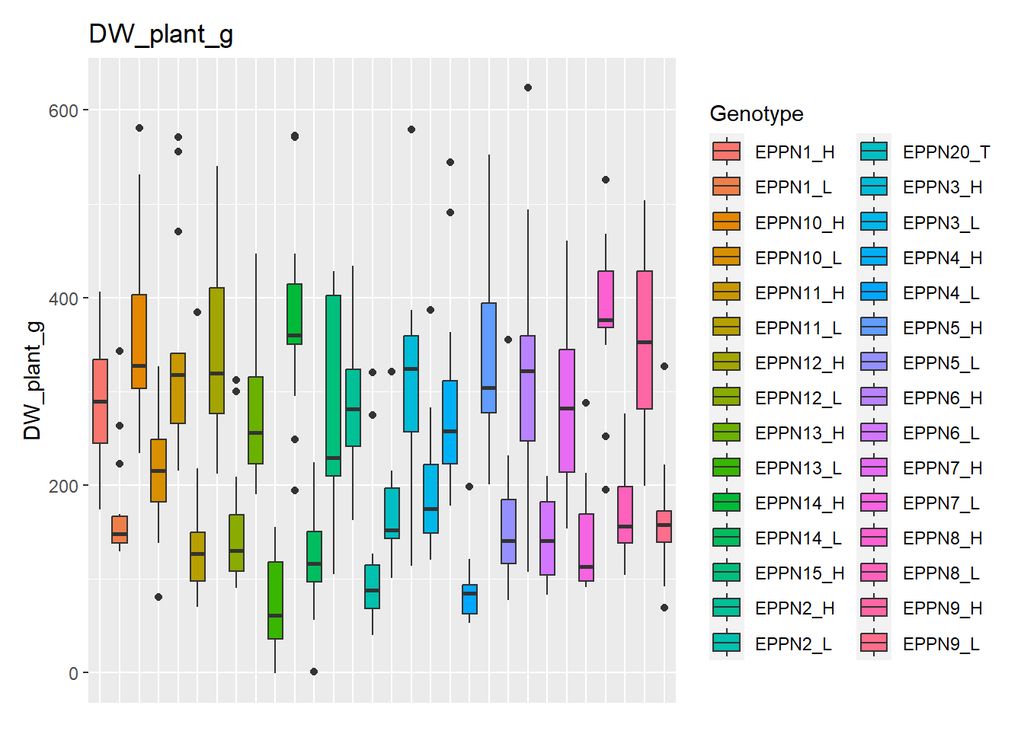

```r
create_boxplots(endpoint, variables, "Genotype")
```

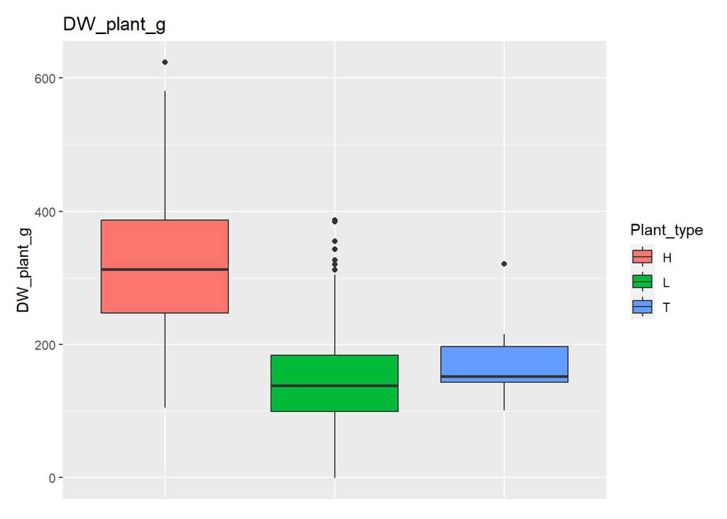

```r
create_boxplots(endpoint, variables, "Plant_type")
```

#### Correlation plots

```r
print(paste0("No data for ", platform))
```

```
## [1] "No data for M3P"
```

## B. Normality hypothesis and outlier detection

Test for normality hypothesis and plot density histogram. The red curve is the normal distribution, the blue dotted curve is the data density curve.

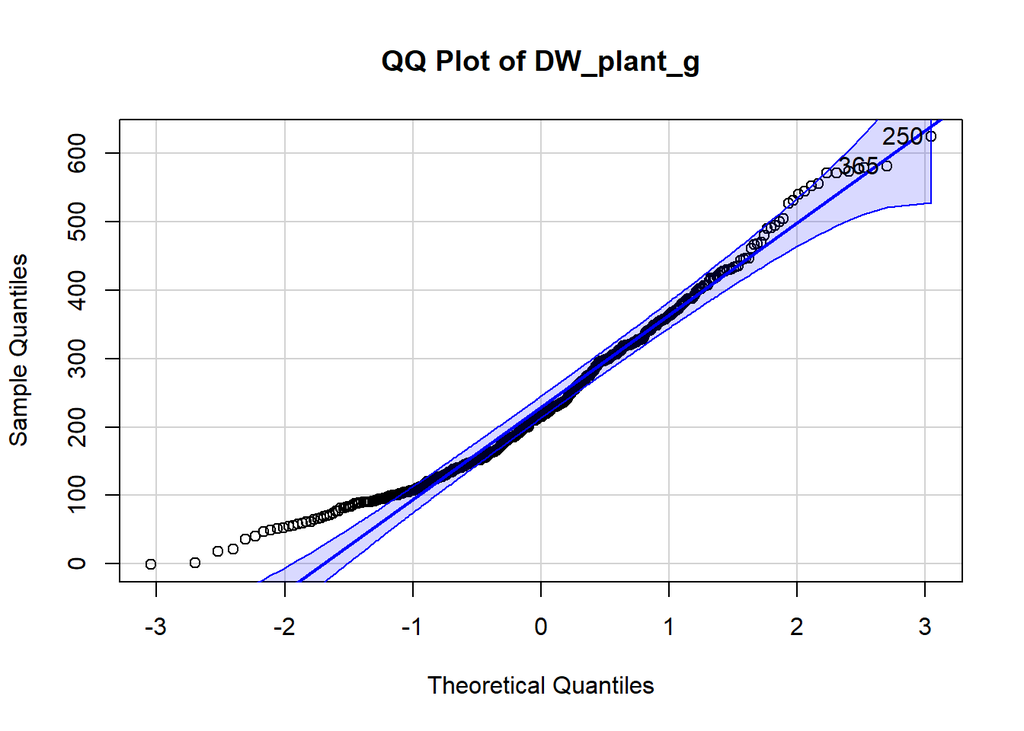

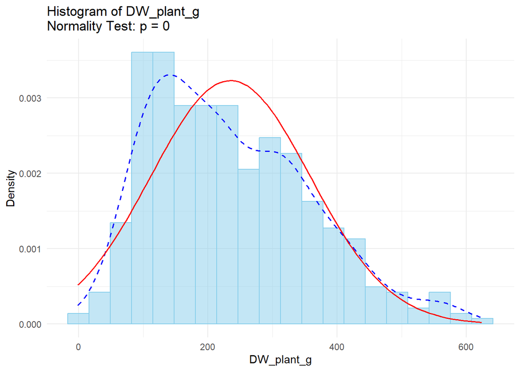

```
## [1] 250 365
```

```r
normality_results <- normality_test_histogram(endpoint)
```

Remove the outliers, replacing them with NULL values and normality visual verification.

The function detect_replace_ouliers_by_genotype checks for outlying values, using the Tukey method.

Then run the function on all variables of the dataset.

```r
endpoint_clean <- endpoint
# Run the function on the dataset for all the variables
endpoint_clean <- detect_replace_outliers_by_genotype(endpoint_clean)
```

### Boxplots after outlier detection

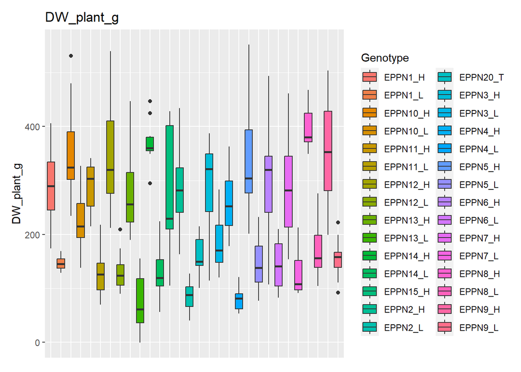

```r
create_boxplots(endpoint_clean, variables, "Genotype")
```

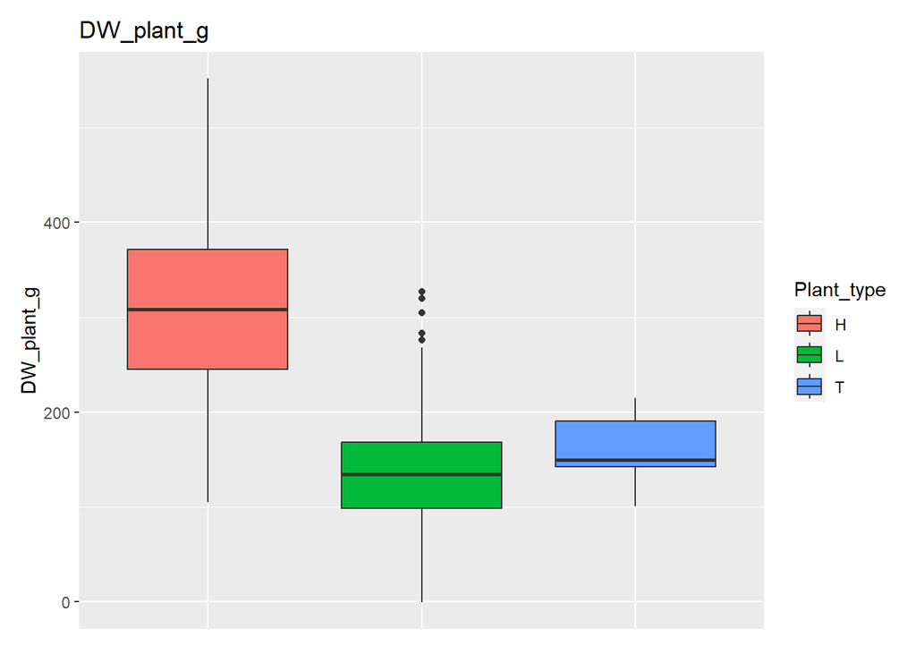

```r
create_boxplots(endpoint_clean, variables, "Plant_type")
```

### Violin and sina plots after outlier detection

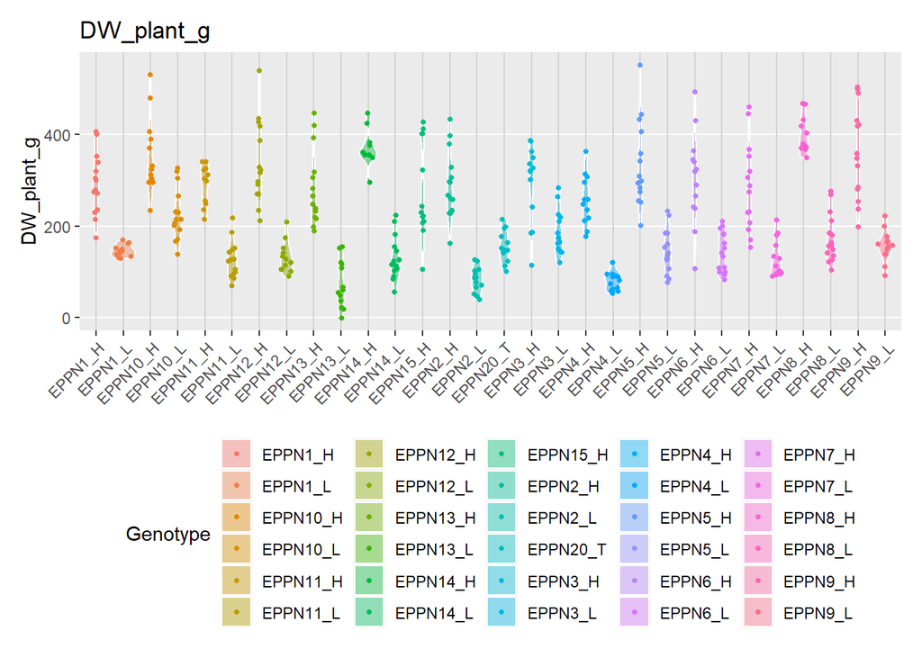

```r
create_violin_plots(endpoint_clean, variables, "Genotype")
```

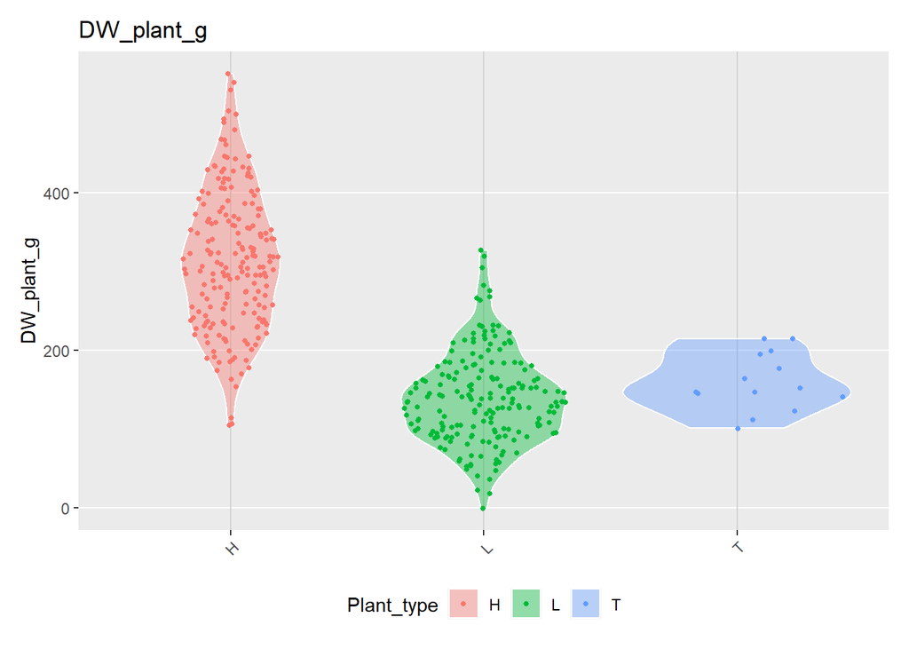

```r
create_violin_plots(endpoint_clean, variables, "Plant_type")
```

### Exploration statistics for the variables after outlier detection

```r
skim(endpoint_clean[variables])
```

Data summary

| Name | endpoint_clean[variables] |
| --- | --- |
| Number of rows | 430 |
| Number of columns | 1 |
| _______________________ |  |
| Column type frequency: |  |
| numeric | 1 |
| ________________________ |  |
| Group variables | None |

**Variable type: numeric**

| skim_variable | n_missing | complete_rate | mean | sd | p0 | p25 | p50 | p75 | p100 | hist |
| --- | --- | --- | --- | --- | --- | --- | --- | --- | --- | --- |
| DW_plant_g | 32 | 0.93 | 225.15 | 113.9 | -1 | 134 | 210 | 306.75 | 552 | ▃▇▆▃▁ |

```r
for (var in variables) {
  cat("\nSummary for:", var, "\n")
  endpoint_clean %>%
    group_by(Genotype) %>%
    summarize(mean    = mean(get(var), na.rm = TRUE),
              std.dev = sd(get(var), na.rm = TRUE),
              n_missing  = sum(is.na(get(var)))) %>%
    arrange(desc(mean)) %>%
    print(n = Inf)
}
```

```
##
## Summary for: DW_plant_g
## # A tibble: 30 × 4
##    Genotype  mean std.dev n_missing
##    <fct>    <dbl>   <dbl>     <int>
##  1 EPPN8_H  400      41.1         3
##  2 EPPN14_H 370.     41.9         4
##  3 EPPN9_H  361.    102.          0
##  4 EPPN10_H 352.     82.1         1
##  5 EPPN12_H 339.     90.9         0
##  6 EPPN5_H  336.     94.1         0
##  7 EPPN6_H  304.    101.          1
##  8 EPPN3_H  294.     85.5         1
##  9 EPPN1_H  293.     67.7         0
## 10 EPPN2_H  291.     74.1         0
```

[output cut: 20 more lines]

# 2. Exploration of the timeseries data

In this part, we look at the timeseries, S_timeseries and T_timeseries datasets, also using several functions, located in the functions.R script.

## Number of data observations per day for the traits of the timeseries datasets

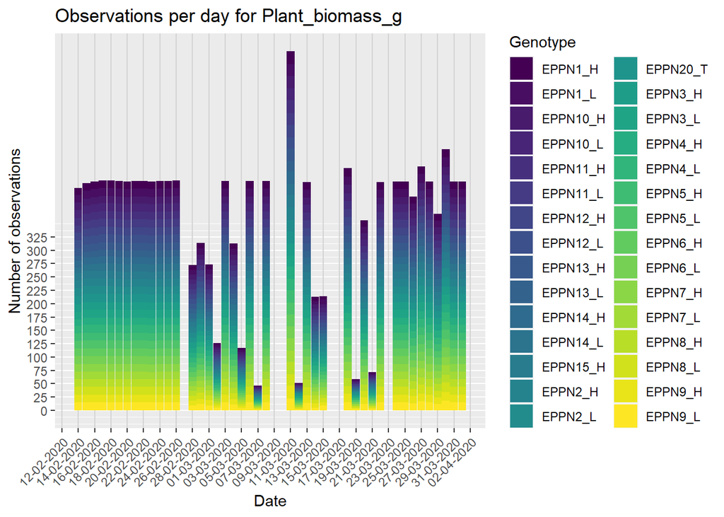

```r
h1 <- ggplot(timeseries, aes(x = Date)) +
  geom_bar(aes(fill = Genotype), position = "stack", width = 0.96) +
  scale_fill_viridis_d(option = "D") +
  labs(x = "Date", y = "Number of observations", title = "Observations per day for Plant_biomass_g") +
  scale_y_continuous(breaks = seq(from = 0, to = 325, by = 25)) +
  scale_x_date(date_breaks = "2 days", date_labels = "%d-%m-%Y") +
  theme(axis.text.x = element_text(angle = 45, hjust = 1),
        panel.grid.major.x = element_line(color = "lightgray", size = 0.5),
        panel.grid.minor.x = element_blank())



h2 <- ggplot(timeseries_Leaf_number, aes(x = Date)) +
  geom_bar(aes(fill = Genotype), position = "stack", width = 0.96) +
  scale_fill_viridis_d(option = "D") +
  labs(x = "Date", y = "Number of observations", title = "Observations per day for Leaf_number") +
  scale_y_continuous(breaks = seq(from = 0, to = 325, by = 25)) +
  scale_x_date(date_breaks = "2 days", date_labels = "%d-%m-%Y") +
  theme(axis.text.x = element_text(angle = 45, hjust = 1),
        panel.grid.major.x = element_line(color = "lightgray", size = 0.5),
        panel.grid.minor.x = element_blank())

h3 <- ggplot(timeseries_Ligulated_leaf_number, aes(x = Date)) +
  geom_bar(aes(fill = Genotype), position = "stack", width = 0.96) +
  scale_fill_viridis_d(option = "D") +
  labs(x = "Date", y = "Number of observations", title = "Observations per day for Ligulated_leaf_number") +
  scale_y_continuous(breaks = seq(from = 0, to = 325, by = 25)) +
  scale_x_date(date_breaks = "2 days", date_labels = "%d-%m-%Y") +
  theme(axis.text.x = element_text(angle = 45, hjust = 1),
        panel.grid.major.x = element_line(color = "lightgray", size = 0.5),
        panel.grid.minor.x = element_blank())

h4 <- ggplot(timeseries_Plant_emergence, aes(x = Date)) +
  geom_bar(aes(fill = Genotype), position = "stack", width = 0.96) +
  scale_fill_viridis_d(option = "D") +
  labs(x = "Date", y = "Number of observations", title = "Observations per day for Plant_emergence") +
  scale_y_continuous(breaks = seq(from = 0, to = 325, by = 25)) +
  scale_x_date(date_breaks = "2 days", date_labels = "%d-%m-%Y") +
  theme(axis.text.x = element_text(angle = 45, hjust = 1),
        panel.grid.major.x = element_line(color = "lightgray", size = 0.5),
        panel.grid.minor.x = element_blank())

h5 <- ggplot(timeseries_Plant_transpiration, aes(x = Date)) +
  geom_bar(aes(fill = Genotype), position = "stack", width = 0.96) +
  scale_fill_viridis_d(option = "D") +
  labs(x = "Date", y = "Number of observations", title = "Observations per day for Plant_transpiration") +
  scale_y_continuous(breaks = seq(from = 0, to = 325, by = 25)) +
  scale_x_date(date_breaks = "2 days", date_labels = "%d-%m-%Y") +
  theme(axis.text.x = element_text(angle = 45, hjust = 1),
        panel.grid.major.x = element_line(color = "lightgray", size = 0.5),
        panel.grid.minor.x = element_blank())

h6 <- ggplot(timeseries_Soil_water_potential, aes(x = Date)) +
  geom_bar(aes(fill = Genotype), position = "stack", width = 0.96) +
  scale_fill_viridis_d(option = "D") +
  labs(x = "Date", y = "Number of observations", title = "Observations per day for Soil_water_potential") +
  scale_y_continuous(breaks = seq(from = 0, to = 325, by = 25)) +
  scale_x_date(date_breaks = "2 days", date_labels = "%d-%m-%Y") +
  theme(axis.text.x = element_text(angle = 45, hjust = 1),
        panel.grid.major.x = element_line(color = "lightgray", size = 0.5),
        panel.grid.minor.x = element_blank())

h7 <- ggplot(timeseries_Water, aes(x = Date)) +
  geom_bar(aes(fill = Genotype), position = "stack", width = 0.96) +
  scale_fill_viridis_d(option = "D") +
  labs(x = "Date", y = "Number of observations", title = "Observations per day for Water") +
  scale_y_continuous(breaks = seq(from = 0, to = 325, by = 25)) +
  scale_x_date(date_breaks = "2 days", date_labels = "%d-%m-%Y") +
  theme(axis.text.x = element_text(angle = 45, hjust = 1),
        panel.grid.major.x = element_line(color = "lightgray", size = 0.5),
        panel.grid.minor.x = element_blank())


h8 <- ggplot(S_timeseries, aes(x = Date)) +
  geom_bar(aes(fill = Genotype), position = "stack", width = 0.96) +
  scale_fill_viridis_d(option = "D") +
  labs(x = "Date", y = "Number of observations", title = "Observations per day for S_timeseries") +
  scale_y_continuous(breaks = seq(from = 0, to = 325, by = 25)) +
  scale_x_date(date_breaks = "2 days", date_labels = "%d-%m-%Y") +
  theme(axis.text.x = element_text(angle = 45, hjust = 1),
        panel.grid.major.x = element_line(color = "lightgray", size = 0.5),
        panel.grid.minor.x = element_blank())
h1
```

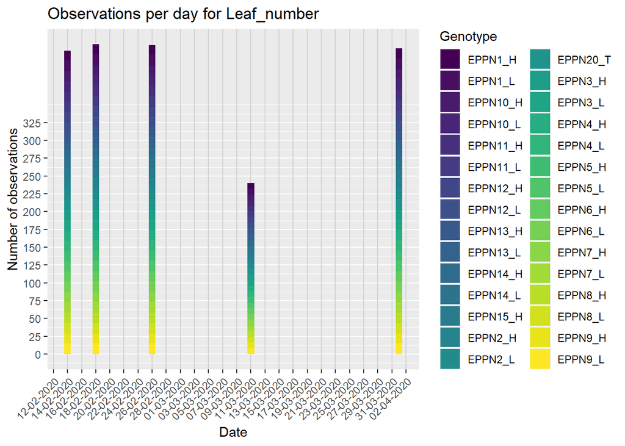

```r
h2
```

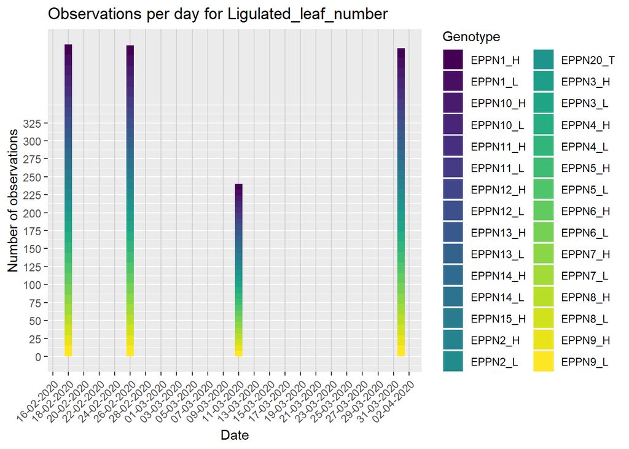

```r
h3
```

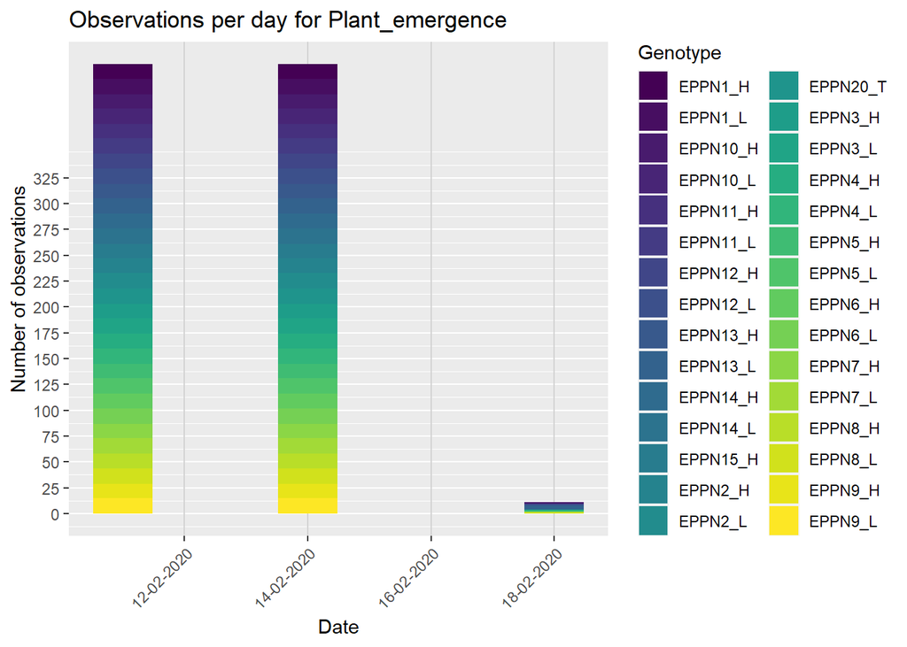

```r
h4
```

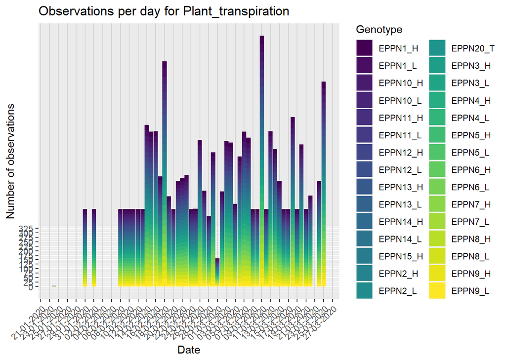

```r
h5
```

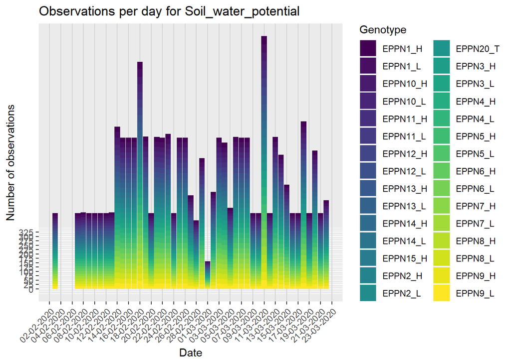

```r
h6
```

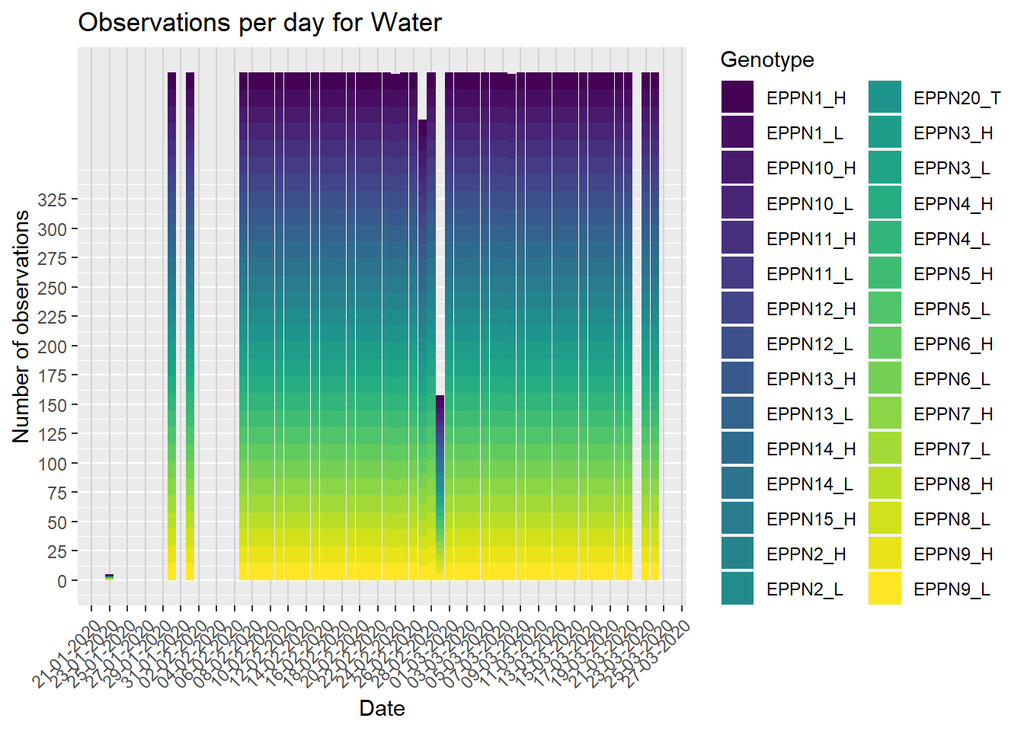

```r
h7
```

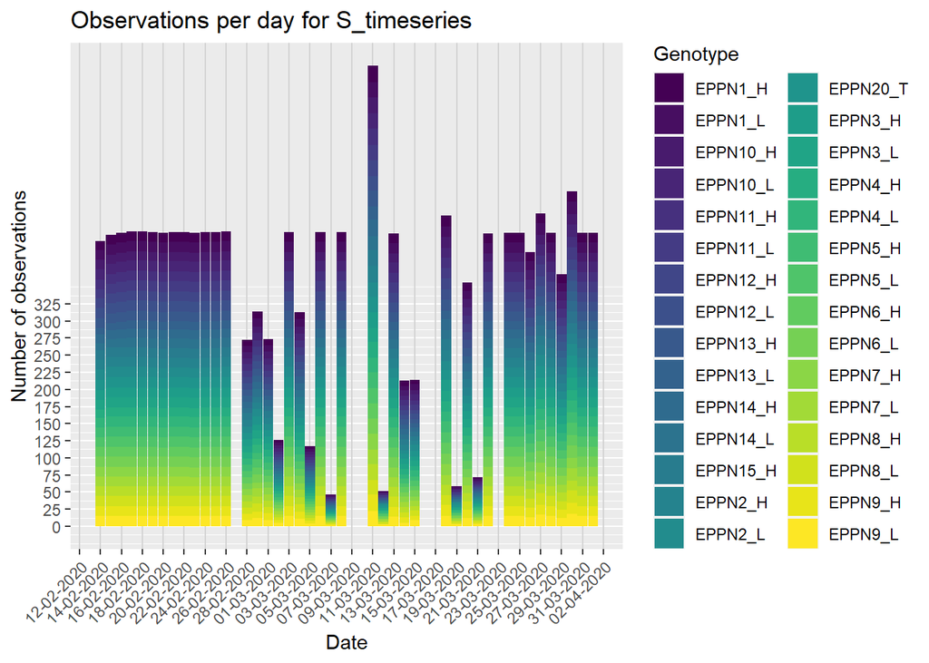

```r
h8
```

## A. Exploration of the timeseries dataframe

Scatter plots by Genotype

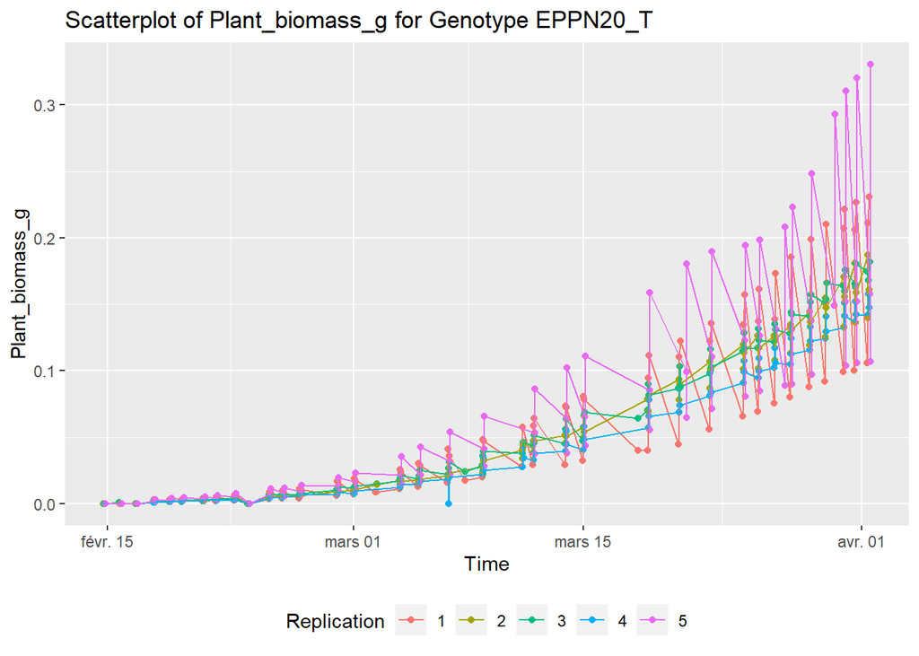

```r
plot_scatter_by_genotype(timeseries, variables_t[1], "EPPN20_T")
```

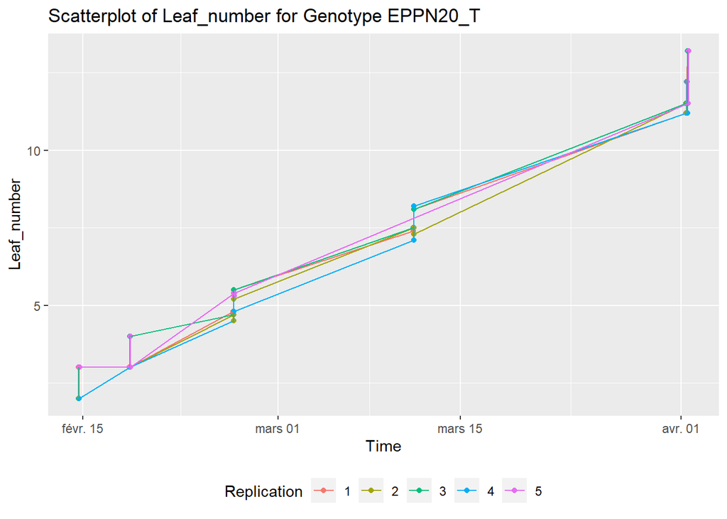

```r
plot_scatter_by_genotype(timeseries_Leaf_number, variables_t[2], "EPPN20_T")
```

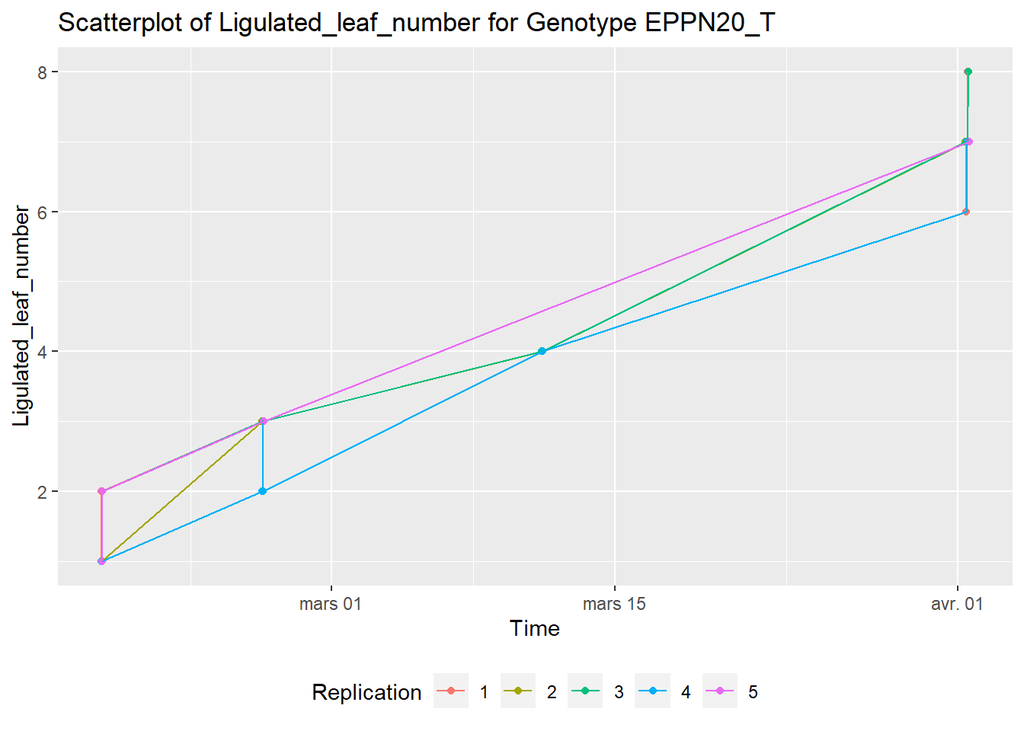

```r
plot_scatter_by_genotype(timeseries_Ligulated_leaf_number, variables_t[3], "EPPN20_T")
```

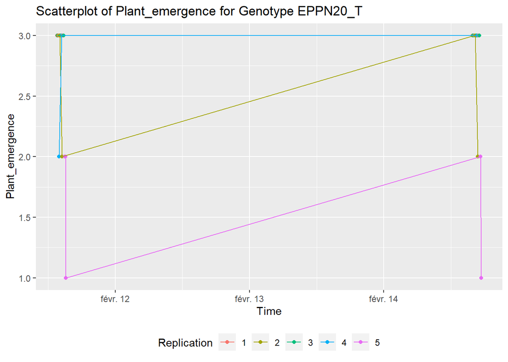

```r
plot_scatter_by_genotype(timeseries_Plant_emergence, variables_t[4], "EPPN20_T")
```

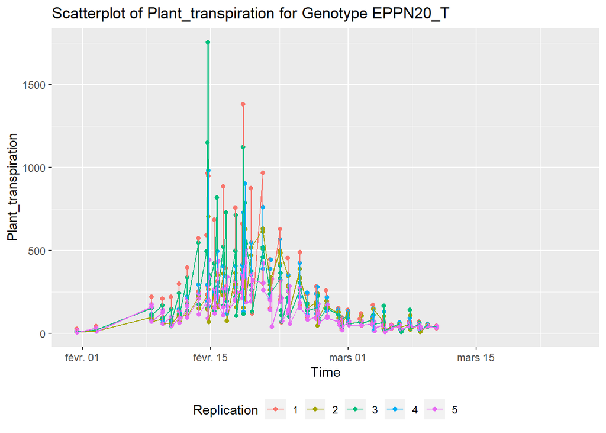

```r
plot_scatter_by_genotype(timeseries_Plant_transpiration, variables_t[5], "EPPN20_T")
```

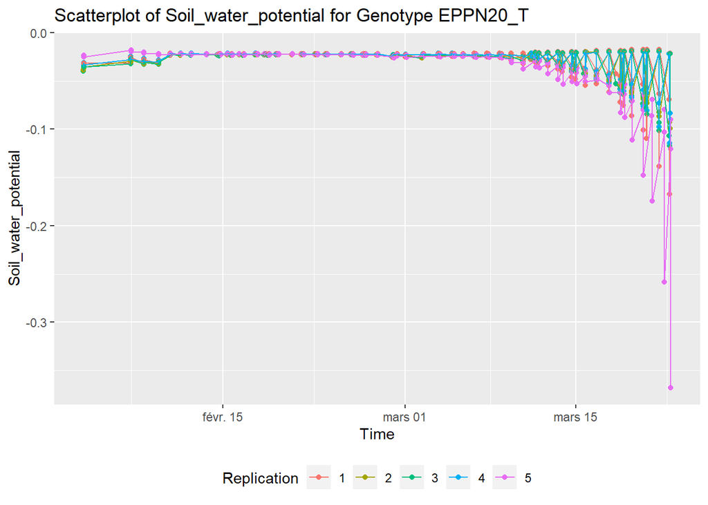

```r
plot_scatter_by_genotype(timeseries_Soil_water_potential, variables_t[6], "EPPN20_T")
```

```r
# Problem for water timeseries data
```

Scatterplots for all genotypes by Plant type (Hybride, Line, EPPN20_T) with smooth line.

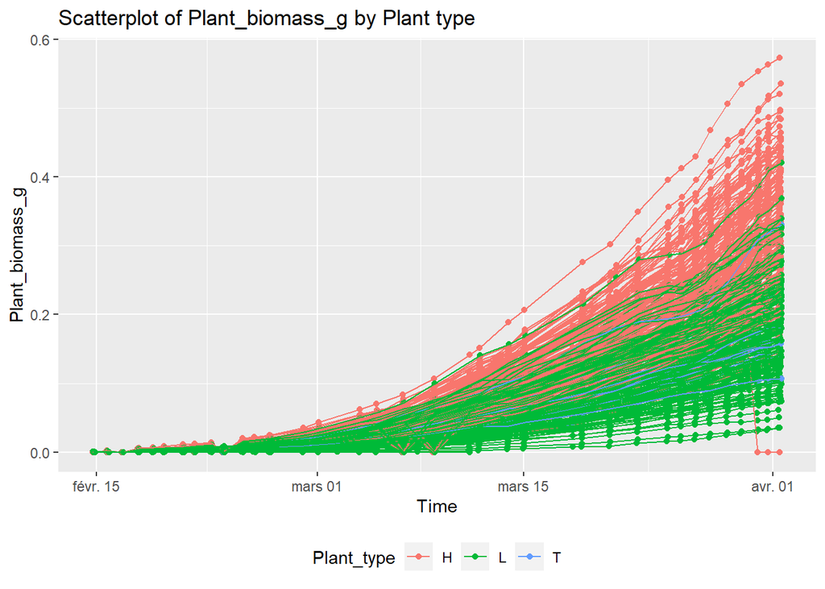

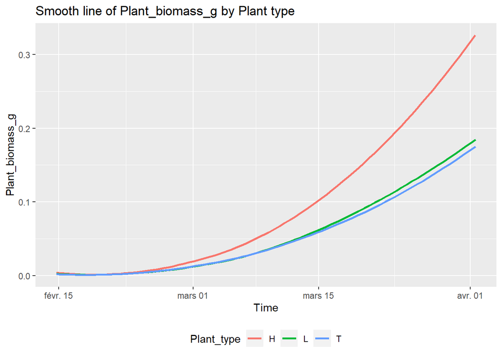

```r
plot_scatter_with_smooth(timeseries, variables_t[1])
```

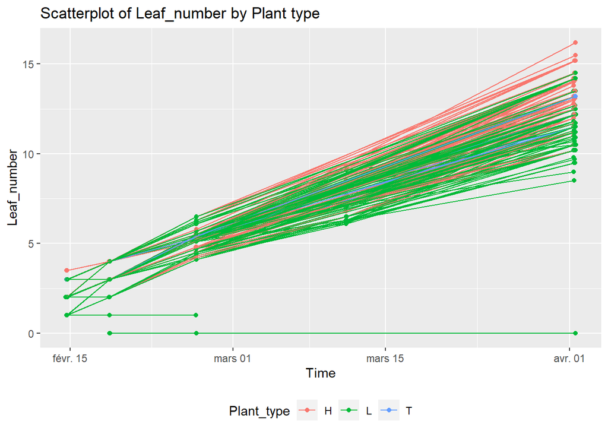

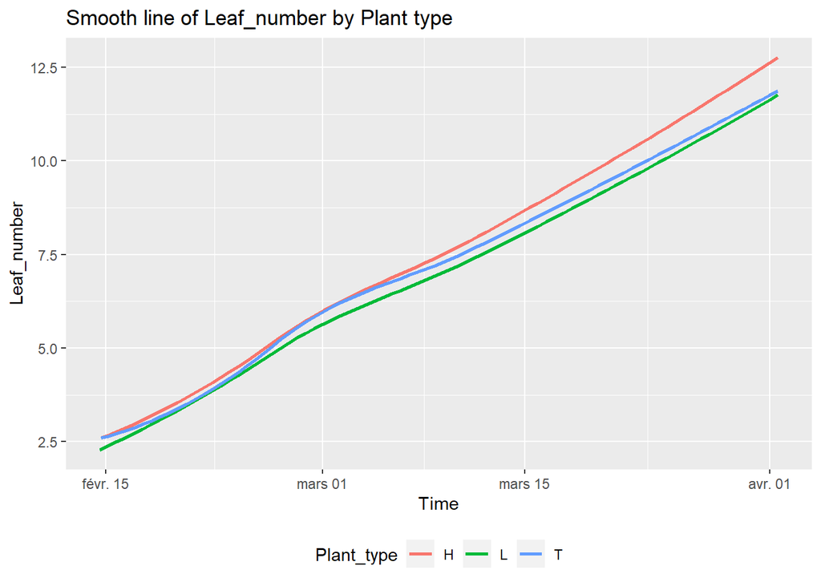

```r
plot_scatter_with_smooth(timeseries_Leaf_number, variables_t[2])
```

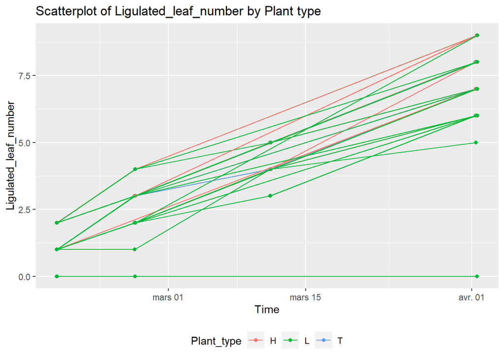

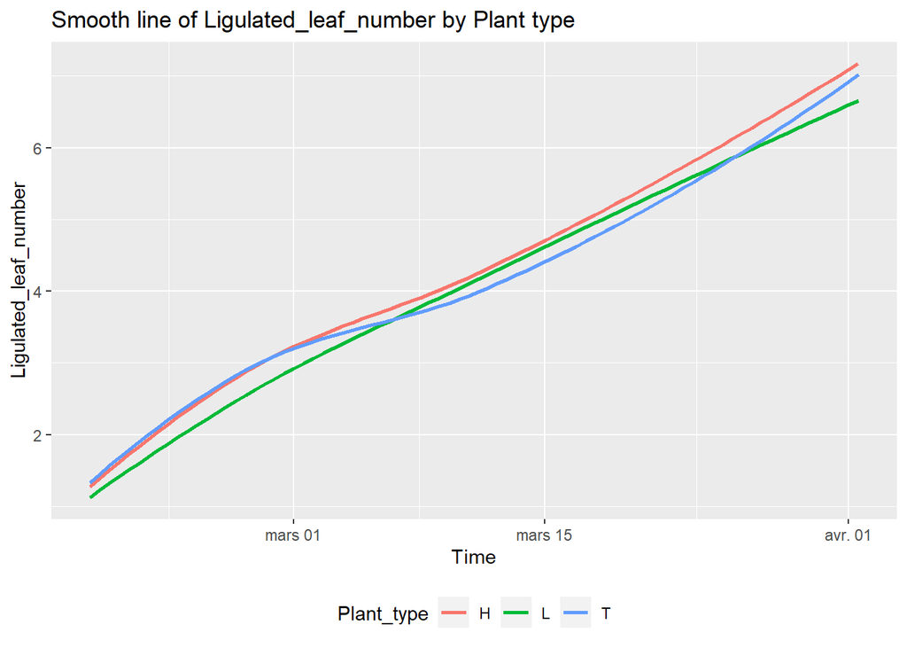

```r
plot_scatter_with_smooth(timeseries_Ligulated_leaf_number, variables_t[3])
```

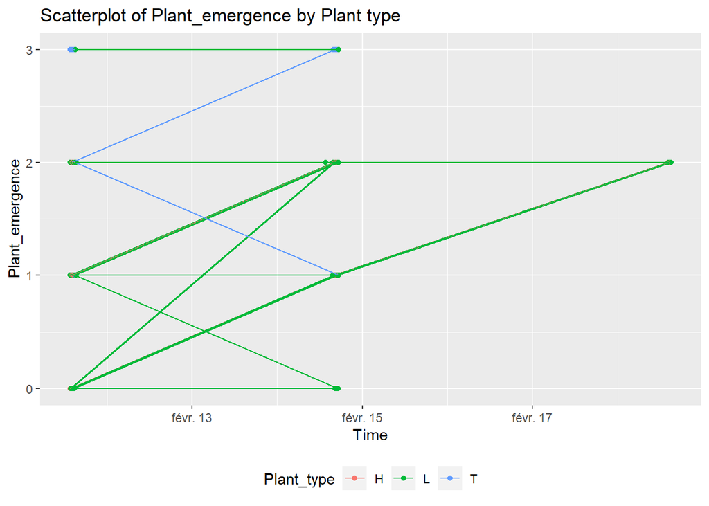

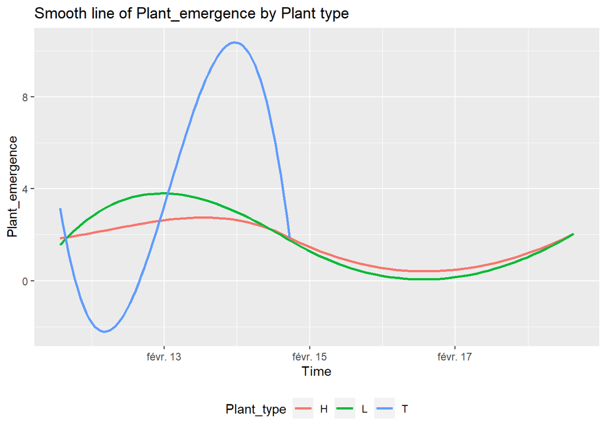

```r
plot_scatter_with_smooth(timeseries_Plant_emergence, variables_t[4])
```